# Reproducible Research: Peer Graded Assignment 1

# Loading and preprocessing the data

### 0. Loading required packages

```r
library(ggplot2)
library(knitr)
library(plyr)
library(dplyr)
library(Hmisc)
```

### 1. Load the data (i.e. read.csv())

Extracting the data from the URL, check for existence in the current working directory and read the data from the csv file.

```r
url1 <- "https://d396qusza40orc.cloudfront.net/repdata%2Fdata%2Factivity.zip"
file1 <- "activity_monitoring_data.zip"

if(!file.exists(file1)) {
  download.file(url1, file1)
  file <- file1
  file.un <- unzip(file)
  unlink(file)
}

AMD <- read.csv("activity.csv")
```

Starting to explore the data.

```r
head(AMD, 10)
```

```
##    steps       date interval
## 1     NA 2012-10-01        0
## 2     NA 2012-10-01        5
## 3     NA 2012-10-01       10
## 4     NA 2012-10-01       15
## 5     NA 2012-10-01       20
## 6     NA 2012-10-01       25
## 7     NA 2012-10-01       30
## 8     NA 2012-10-01       35
## 9     NA 2012-10-01       40
## 10    NA 2012-10-01       45
```

```r
str(AMD)
```

```
## 'data.frame':    17568 obs. of  3 variables:
##  $ steps   : int  NA NA NA NA NA NA NA NA NA NA ...
##  $ date    : Factor w/ 61 levels "2012-10-01","2012-10-02",..: 1 1 1 1 1 1 1 1 1 1 ...
##  $ interval: int  0 5 10 15 20 25 30 35 40 45 ...
```

### 2. Process/transform the data (if necessary) into a format suitable for your analysis

Changing the $date variable from factor type to date type.

```r
AMD$date <- as.Date(AMD$date)
str(AMD)
```

```
## 'data.frame':    17568 obs. of  3 variables:
##  $ steps   : int  NA NA NA NA NA NA NA NA NA NA ...
##  $ date    : Date, format: "2012-10-01" "2012-10-01" ...
##  $ interval: int  0 5 10 15 20 25 30 35 40 45 ...
```

# What is mean total number of steps taken per day?

### 1. For this part of the assignment, you can ignore the missing values in the dataset.

Subsetting for only complete cases.

```r
AMDC <- subset(AMD, complete.cases(AMD))
```

### 2. Calculate the total number of steps taken per day.

Performing a calculation of the number of steps from the subsetted data.

```r
nsteps <- aggregate(steps ~ date, data = AMDC, FUN = sum)
```

### 3. Calculate and report the mean and median of the total number of steps taken per day

```r
meansteps <- mean(nsteps$steps)
meansteps
```

```
## [1] 10766.19
```

```r
mediansteps <- median(nsteps$steps)
mediansteps
```

```
## [1] 10765
```

### 4. Make a histogram of the total number of steps taken each day

Plotting the steps per day and showing the mean/median by the use of a line indicator.

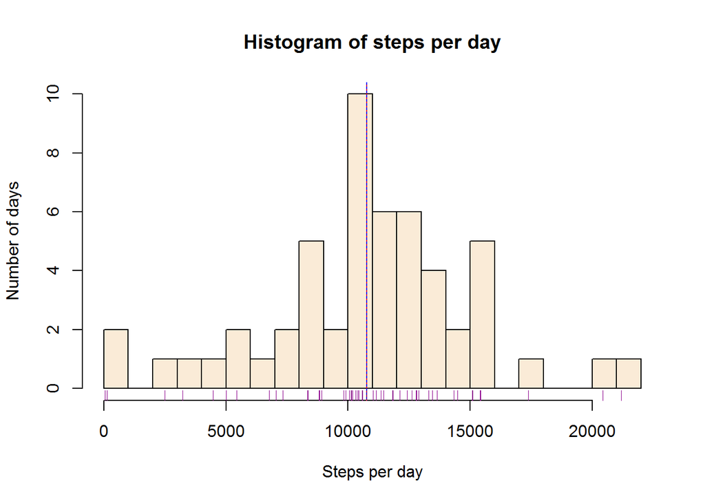

```r
hist(nsteps$steps, breaks = 20, col = "antiquewhite", xlab = "Steps per day", ylab = "Number of days", main = "Histogram of steps per day")
abline(v=mean(nsteps$steps), lty=1, col="blue1")                   # draw a blue line thru the mean
abline(v=median(nsteps$steps), lty=3, col="red")                   # draw a red line thru the median
text(mean(nsteps$steps),25,labels="mean", pos=4, col="blue1")      # label the mean
text(median(nsteps$steps),23,labels="median", pos=4, col="red")   # label the median
rug(nsteps$steps, col="darkmagenta")
```

# What is the average daily activity pattern?

### 1. Make a time series plot (i.e. type = “l”) of the 5-minute interval (x-axis) and the average number of steps taken, averaged across all days (y-axis)

Plotting a time series plot.

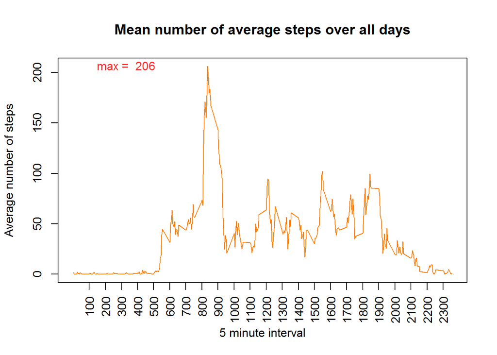

```r
tsp <- aggregate(steps ~ interval, AMDC, mean)

plot(tsp$interval, tsp$steps, type = "l", xaxt = "n", col = "darkorange1", main = "Mean number of average steps over all days", xlab = "5 minute interval", ylab = "Average number of steps")
axis(1, at = seq(100, 2300, by = 100), las = 2)
text(which.max(tsp$steps),max(tsp$steps),
     labels=paste("max = ",as.character(round(max(tsp$steps)))),
     pos=4, col="firebrick1")
```

### 2. Which 5-minute interval, on average across all the days in the dataset, contains the maximum number of steps?

Calculating the max steps - 5 minute interval.

```r
max_steps_interval <- which.max(tsp$steps)
print(signif(tsp[max_steps_interval,]), 1)
```

```
##     interval  steps
## 104      835 206.17
```

# Imputing missing values

### 1. Note that there are a number of days/intervals where there are missing values (coded as NA). The presence of missing days may introduce bias into some calculations or summaries of the data.

### 1.1 Calculate and report the total number of missing values in the dataset (i.e. the total number of rows with NAs)

Plotting a bar graph with the missing values count.

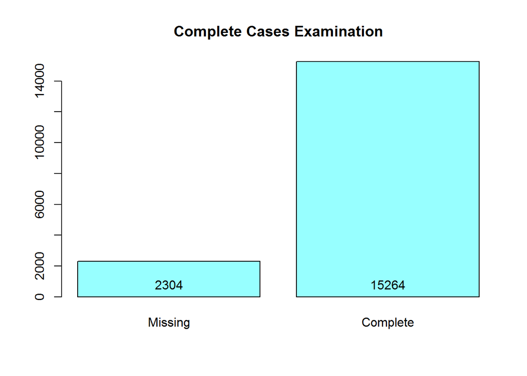

```r
originalValue <- complete.cases(AMD)
nMissing <- length(originalValue[originalValue == FALSE])                      # number of records with NA
nComplete <- length(originalValue[originalValue == TRUE])                      # number of complete records

title="Complete Cases Examination"
barplot(table(originalValue),main=title,xaxt='n', col="darkslategray1")      # render Complete Cases barplot
axis(side=1,at=c(.7,1.9),labels=c("Missing","Complete"),tick=FALSE)          # render axis
text(.7,0,labels=nMissing, pos=3)                                            # label the NA's bar
text(1.9,0,labels=nComplete, pos=3)
```

Calculating the missing values with a function.

```r
paste("The number of missing values is",nMissing)
```

```
## [1] "The number of missing values is 2304"
```

### 2. Devise a strategy for filling in all of the missing values in the dataset.

### 2.1 Create a new dataset that is equal to the original dataset but with the missing data filled in.

Imputing the data.

```r
AMDI <- AMD
AMDI$steps <- impute(AMD$steps, fun=mean)
```

### 3. Make a histogram of the total number of steps taken each day

Plotting a histogram from the imputed data.

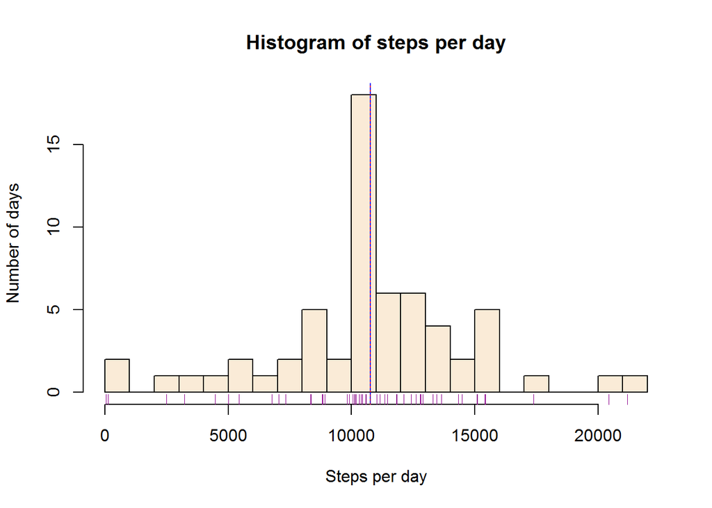

```r
nsteps2 <- aggregate(steps ~ date, data = AMDI, FUN = sum)

hist(nsteps2$steps, breaks = 20, col = "antiquewhite", xlab = "Steps per day", ylab = "Number of days", main = "Histogram of steps per day")
abline(v=mean(nsteps$steps), lty=1, col="blue1")                   # draw a blue line thru the mean
abline(v=median(nsteps$steps), lty=3, col="red")                   # draw a red line thru the median
text(mean(nsteps$steps),25,labels="mean", pos=4, col="blue1")      # label the mean
text(median(nsteps$steps),23,labels="median", pos=4, col="red")   # label the median
rug(nsteps$steps, col="darkmagenta")
```

# Are there differences in activity patterns between weekdays and weekends?

### 1. Create a new factor variable in the dataset with two levels - “weekday” and “weekend” indicating whether a given date is a weekday or weekend day.

Creating a factor variable.

```r
AMDI$dateType <-  ifelse(as.POSIXlt(AMDI$date)$wday %in% c(0,6), 'weekend', 'weekday')
```

### 2. Make a panel plot containing a time series plot

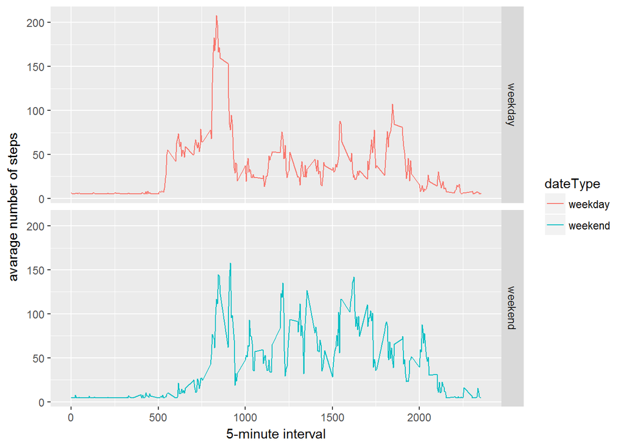

```r
averagedAMDI <- aggregate(steps ~ interval + dateType, data=AMDI, mean)
ggplot(averagedAMDI, aes(interval, steps, color = dateType)) +
  geom_line() +
  facet_grid(dateType ~ .) +
  xlab("5-minute interval") +
  ylab("avarage number of steps")
```

The graph looks less skewed and more uniform on weekends, probably due to an increase in outdoor activities during weekends.